# R as a Teaching Tool

June 5th, 2015

## Putting this Talk in Context

### Past INRUG Meetings

- reproducibility (`rmarkdown`)
- visualization (`ggplot2` and `shiny`)
- data cleaning and wrangling (`tidyr` and `dplyr`)

### A Few Remarks for Today

- we'll talk about teaching statistics (theory), not data science
- national recommendations for statistics pedagogy call for a tool such as R
- theory can't be compromised for neat tricks in R

### Recent Efforts

- make R more accessible for intro stats courses
- include visualization and simulation to *complement* an intro stats course
- incorporate aspects of Data Science in an intro stats course

## Who Am I?

### My Training

- applied mathematician and probabilist, but not a really a statistician…
- enthusiastic user of R for ~1-2 years

### Courses I Teach

- calculus sequence, differential equations, …, linear algebra, and *statistics*
  - MATH 121: introductory statistics
  - MATH 321: calculus-based introductory statistics
  - MATH 421/422: proof-based probability and statistics

### Why I'm Partial to Using Mathematical/Statistical Software

- computational thinking and literacy
- provides a mechanism for inquiry via exploration, experimentation, and discovery
- move beyond the (often tedious) formulas and grapple with the more interesting questions
- appreciate the increasing role that computation plays in mathematics
  - software is **no** replacement for *understanding* the underlying concepts for the calculations

## Recent R-related Activities

[figure not shown]

- Project NExT workshop on *Teaching Intro Stats* (Aug. 2014)
  - Carolyn Cuff (Westminster)
- MAA-StatEd (since Aug. 2014)
- Isolated Statisticians Network (since Aug. 2014)
- Inland Northwest R Users Group (since Aug. 2014)
- Minicourse at JMM on *Project MOSAIC* (Jan. 2015)
  - Nick Horton (Amherst) and Randy Pruim (Calvin)
- USCOTS at Penn. St. University (May 2015)
- Workshop at USCOTS on *Data Science in R Studio* (May 2015)
  - Nick Horton (Amherst) and Daniel Kaplan (Macalester)

### Upcoming

- MAA MathFest (Aug. 2015)
- *Joint Statistical Meeting in Seattle, WA (Aug. 2015)*

## Recommendations for Statistics Pedagogy

### GAISE Recommendations:

1. emphasize statistical literacy and develop statistical thinking
2. use real data
3. use technology for developing concepts and analyzing data
   - *"to the maximum extent feasible, calculations and graphics should be automated."*
4. stress conceptual understanding, rather than mere knowledge of procedures

\(\star\) read more at http://www.amstat.org/education/gaise/

### ASA Curriculum Guidelines:

1. increased importance of data science
2. real applications
3. more diverse models and approaches
4. ability to communicate

\(\star\) read more at http://www.amstat.org/education/curriculumguidelines.cfm

## Technology and Software

Some sort of software is necessary, but which and how?

- instructor demonstrations vs. hands-on experience?
- possible software: R Studio, Minitab, SPSS, SAS/JMP, Deducer/RCmdr, StatCrunch, etc.
- online applets: [StatKey](http://lock5stat.com/statkey/), Rossman-Chance, etc.

### R is…

- "R is a free software environment for statistical computing and graphics.  
  It compiles and runs on a wide variety of UNIX platforms, Windows and MacOS"
  - The R Project Organization
- "R is a data analysis software; R is a programming language; R is an  
  environment for statistical analysis; R is open-source; R is a community"
  - http://www.inside-r.org
- "R is extremely powerful"
  - Revolution Analytics

## So, Why R?

## Why R?

- free and open source
  - SAS, SPSS, Maple, Mathematica, MATLAB, etc. are expensive
  - valuable and employable skill (accessible after graduation)
- R is growing (rapidly in popularity)
  - http://blog.revolutionanalytics.com/popularity/
- students won't outgrow it (it will grow *with* them)
- instructional data is pre-loaded
- R provides a *gentle* introduction to coding, computation, and \(\LaTeX\)
- reproducible rather than point, drag, click, copy/paste, cross-your-fingers, …
- high-quality graphics
- clear and intuitive workflow

## How Have I Incorporated R?

## A Tale of Two Semesters

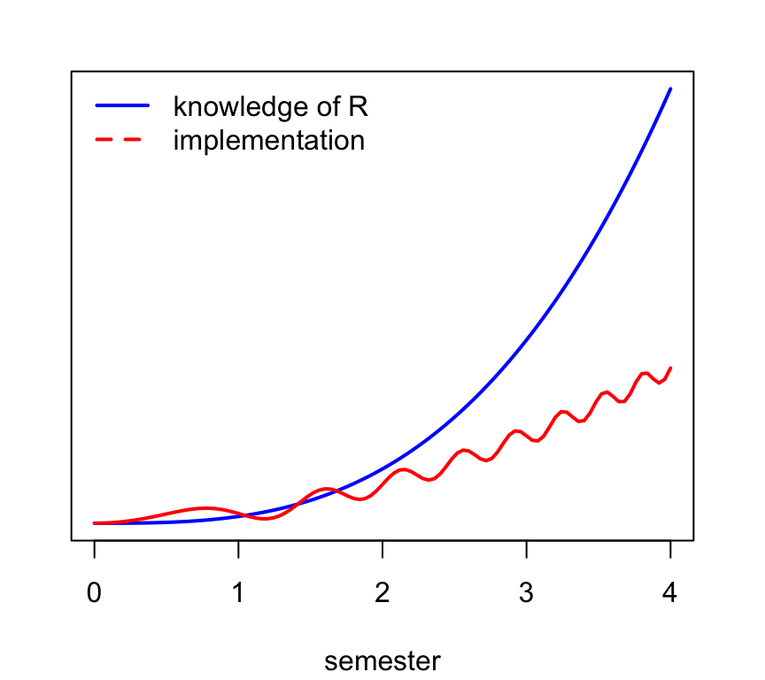

### Fall 2014

- R via SageMathCloud (**not** R Studio)
- regular in-class demonstrations
  - R code embedded into \(\LaTeX\)
- group writing projects (used R outside of class)
- in-class labs (scheduled on the fly)

### Spring 2015

- R via R Studio (limited access outside of class)
- regular in-class demonstrations
  - notes in R Markdown; shiny applications
- **no** group projects
- in-class labs (scheduled from day 1)

## Lecture

R is used in some fashion for ~75% of my lectures

- planned demonstrations (static and/or interactive)
- simulations and graphics on the fly
- post notes online in HTML format

### Examples of Notes and R Code

- permutation hypothesis tests
- continuous RVs
- simple linear regression

### Examples of `shiny` Applications

- confidence intervals
- Type I and II errors

## Group Writing Projects

In-depth exploration of a concept

- groups are often asked to play the role of a consulting company
  - inspired by Gavin Larose (Univ. of Michigan)
- use R outside of class; wrestle with R on their own
- made R relevant and important
- formed collaborative groups (and aided rapport)
- students are given the `.Rmd` file to edit
  - they begin to take pride in producing high-quality documents

### Examples

- Descriptive Statistics
- Airline Overbooking
- Planning a Picnic

## Labs

In-class labs are held in College 243

- focused on discovery and inquiry
  - rather than learn concepts and R at the same time
- collaborative teams encouraged
- use R while exploring material from a different perspective
- bimodal response from students (useful vs. waste of time)

### Example

- drug efficacy via `sleep` dataset

## Example (drug efficacy via `sleep` dataset)

With provided code, students create plots similar to these:

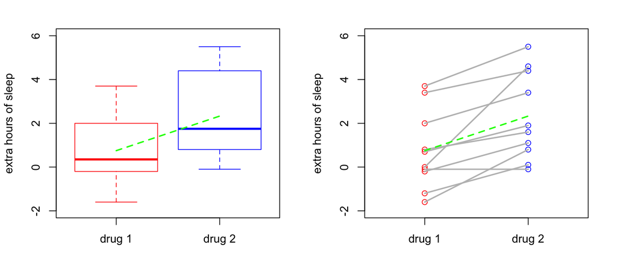

Next time, I'll have students explore with `mplot` instead.

## Project MOSAIC (http://mosaic-web.org/)

A predominant philosophy: [*Less Volume, More Creativity*](http://cran.r-project.org/web/packages/mosaic/vignettes/LessVolume-MoreCreativity.html)

- `xpnorm`, `xqnorm`, `xpt`, `xqt`, `favstats`, `tally`, `do`, etc. are functions built in the mosaic package
- `mplot`, `mScatter`, `mWrangle`, `mBar`, etc. are functions that utilize the `manipulate` package

### Freely available books:

- A Compendium of Commands to Teach Statistics with R
- Start Teaching Statistics Using R
- Start R in Calculus

### Other instructional material:

- under development by Horton, Kaplan, and Pruim, e.g., [activity](http://dtkaplan.github.io/USCOTS-2015/Handouts/WhatHappenedToJane/WhatHappenedToJane.html)/[key](http://dtkaplan.github.io/USCOTS-2015/Handouts/WhatHappenedToJane/WhatHappenedToJane-answers.html) and [activity](http://dtkaplan.github.io/USCOTS-2015/Handouts/BikeSharing/BikeSharingBasics.html)/[key](http://dtkaplan.github.io/USCOTS-2015/Handouts/BikeSharing/BikeSharingBasics-Answers.html)

## "Less Volume, More Creativity"

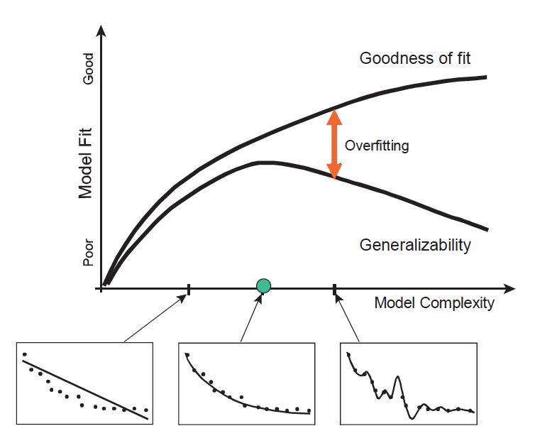

- less number of R commands, but each with more flexibility and power
- provide enough commands so that students can do something, but not so many that it is overwhelming
- avoid programming aspects (`if`, `for`, etc.)
- give students the bare minimum and make them "beg" for more

### A Quote to Live By

- "if R is the hardest thing in the course, then the R is too hard and your questions are too easy"
  - R. Pruim (2015)

## Useful Educational Tools in a Statistics Clases

### `mplot`

- powerful way to both do data exploration as well as learn `ggplot2`

```r
require(mosaic)
require(manipulate)
mplot(ToothGrowth)
```

### `mosaic` and `manipulate`

```r
xqnorm(0.975,5,7)
manipulate(xqnorm(alpha,verbose=FALSE),alpha = slider(0.001,0.999,step=0.001))
```

## Useful Educational Tools in a Statistics Clases

### `mWrangle`

- several *Data Science* courses are popping up around the country and spend ~1/3 to ~1/2 of the time on data wrangling
- how to *easily* include it in an introductory course?
  - maybe `mWrangle` (currently in development) or http://rstudio.calvin.edu:3838/rpruim/dataOps/

```r
require(DCF)
require(DCFinteractive)
require(mosaicData)
mWrangle(KidsFeet)
```

## How Has it all Worked?

Enhancement or Distraction?

## Struggles and Surprises

### Selling R To Students

- R can be tough to sell (it's *free*, remember?)
- the exposure to R seems conducive to learning and to have a positive impact on retention
  - but it may not help a student immediately, e.g., on the next exam
- *some* students have really invested themselves in learning R

### Lab Space

- the mathematics department has **no** lab space; A&S has limited lab space
  - a 10 person seat license for Mathematica
- R Studio on a server, using personal machines, and SageMathCloud are each options

### R Changes Things

MATH 321 with R (i.e., students *using* R) is fundamentally different than without R

How much math? How much data? How much R?

- the "correct" balance changes from MATH 121 to MATH 321 to MATH 421

## Bigger Picture and Future Directions

### Keep Learning R

- based off of GAISE recommendations (and others), software is necessary
  - R is one viable (and good) option
- more deeply connects students to important concepts
- provides a computational tool for exploration
- fundamentally changed my course organization and structure
  - ease of creating lecture notes and interactive demonstrations

### Possible Directions

- interactive webpages
- partially flipped classroom
  - expose students to software before coming to class
- more writing projects and less exams
- randomized notes, examples, HWs, textbooks, etc.

## Ending with More Questions than Answers

### SoTL Questions Regarding R

- how best to deliver the material to students?
  - labs, demonstrations, and/or group projects?
  - potential for pseudo-flipped classroom
- how does using R impact learning?
- how does using R impact attitude/interest?
- how should testing be done?
  - with or without R?
- this is a **math** class about the study of **data**
  - does incorporating data help or hurt the learning of the material?
  - showing neat tricks in R is not a replacement for learning the (mathematical) content

### How Well Would R Work in a Calculus Course?

## Acknowledgements and Thanks

- Inland Northwest R Users Group
- Project NExT cohort and Isolated Statisticians
- A&S for funding to participate in Project NExT
- CTA for funding to attend USCOTS
- Mathematics Department for their support